# Homework 1

## Instructions

Your HW submission should consist of **one pdf file** exported from the Jupyter Notebook containing the answers to all the questions included in the homework.

You will use Jupyter Notebook exclusively for this homework. All the cells in this notebook is editable. You need to edit, insert `markdown` and `code` cells to complete the homework.

> If you are running this notebook on MyBinder, be sure to download your notebook, otherwise all your progress will be lost. You will need to reupload your notebook to MyBinder next time to restore progress.

> If you are running this notebook locally on your own machine, you can simply save the notebook.

> AVOID writing all your codes in a single cell if there are multiple lines with meaningful outputs. Separate them and insert new cells as you see fit.

**Student Info**

## Question 1: Basic Operations

1. (0.2 points) Import the laptop sales dataset, give it a proper name

```r
# Please input your code here
sale_data <- read.csv("LaptopSales.csv", encoding = "UTF-8")
sale_data
```

| X.U.FEFF.Date | Configuration | Customer.Postcode | Store.Postcode | Retail.Price | Screen.Size..Inches. | Battery.Life..Hours. | RAM..GB. | Processor.Speeds..GHz. | Integrated.Wireless. | HD.Size..GB. | Bundled.Applications. | OS.X.Customer | OS.Y.Customer | OS.X.Store | OS.Y.Store | CustomerStoreDistance |
| --- | --- | --- | --- | --- | --- | --- | --- | --- | --- | --- | --- | --- | --- | --- | --- | --- |
| 2008/01/01 00:01:19 | 163 | EC4V 5BH | SE1 2BN | 455 | 15 | 5 | 1 | 2.0 | Yes | 80 | Yes | 532041 | 180995 | 534057 | 179682 | 2405.8730 |
| 2008/01/01 00:02:52 | 320 | SW4 0JL | SW12 9HD | 545 | 15 | 6 | 1 | 2.0 | No | 300 | No | 529240 | 175537 | 528739 | 173080 | 2507.5586 |
| 2008/01/01 00:04:18 | 23 | EC3V 1LR | E2 0RY | 515 | 15 | 4 | 1 | 2.0 | Yes | 300 | Yes | 533095 | 181047 | 535652 | 182961 | 3194.0014 |
| 2008/01/01 00:04:40 | 169 | SW1P 3AU | SE1 2BN | 395 | 15 | 5 | 1 | 2.0 | No | 40 | Yes | 529902 | 179641 | 534057 | 179682 | 4155.2023 |
| 2008/01/01 00:06:04 | 365 | EC4V 4EG | SW1V 4QQ | 585 | 15 | 6 | 2 | 2.0 | No | 120 | Yes | 531684 | 180948 | 528924 | 178440 | 3729.2981 |
| 2008/01/01 00:12:26 | 309 | W1B 5PX | SW1V 4QQ | 555 | 15 | 6 | 1 | 2.0 | Yes | 120 | Yes | 529207 | 180969 | 528924 | 178440 | 2544.7849 |
| 2008/01/01 00:14:32 | 75 | SE25 4LX | SE8 3JD | 465 | 15 | 4 | 2 | 2.0 | No | 80 | Yes | 534575 | 168236 | 537175 | 177885 | 9993.1577 |
| 2008/01/01 00:17:13 | 346 | N7 6AR | E2 0RY | 450 | 15 | 6 | 2 | 1.5 | No | 40 | No | 530461 | 186176 | 535652 | 182961 | 6105.9566 |
| 2008/01/01 00:24:08 | 70 | W3 7JT | SW18 1NN | 455 | 15 | 4 | 2 | 2.0 | Yes | 120 | No | 520898 | 180071 | 525155 | 175180 | 6484.1291 |
| 2008/01/01 00:56:50 | 351 | SW8 1RB | SW1V 4QQ | 620 | 15 | 6 | 2 | 1.5 | No | 300 | Yes | 530298 | 177435 | 528924 | 178440 | 1702.3222 |
| 2008/01/01 01:00:49 | 209 | SE26 5HB | CR7 8LE | 465 | 15 | 5 | 2 | 2.0 | Yes | 40 | Yes | 535838 | 171458 | 532714 | 168302 | 4440.6882 |
| 2008/01/01 01:03:25 | 359 | W1T 1DG | NW5 2QH | 665 | 15 | 6 | 2 | 2.0 | Yes | 300 | Yes | 529584 | 181554 | 529248 | 185213 | 3674.3948 |
| 2008/01/01 01:05:10 | 300 | TW9 3AH | W4 3PH | 440 | 15 | 6 | 1 | 1.5 | No | 80 | No | 518891 | 177662 | 519585 | 177640 | 694.3486 |
| 2008/01/01 01:07:08 | 363 | N1 9DU | SW1V 4QQ | 565 | 15 | 6 | 2 | 2.0 | No | 80 | Yes | 530451 | 183067 | 528924 | 178440 | 4872.4591 |
| 2008/01/01 01:15:42 | 22 | N1 8LU | E2 0RY | 405 | 15 | 4 | 1 | 2.0 | Yes | 120 | No | 531957 | 183906 | 535652 | 182961 | 3813.9284 |
| 2008/01/01 01:18:44 | 53 | E14 0BB | SE8 3JD | 480 | 15 | 4 | 2 | 1.5 | Yes | 120 | Yes | 538189 | 180731 | 537175 | 177885 | 3021.2435 |
| 2008/01/01 01:29:40 | 310 | WC1X 0AE | SW1P 3AU | 505 | 15 | 6 | 1 | 2.0 | Yes | 120 | No | 531065 | 182190 | 529902 | 179641 | 2801.7798 |
| 2008/01/01 01:30:52 | 314 | N1 9BL | SE1 2BN | 425 | 15 | 6 | 1 | 2.0 | No | 40 | No | 530520 | 183119 | 534057 | 179682 | 4931.8696 |
| 2008/01/01 01:32:30 | 320 | WC2E 8RF | SE1 2BN | 545 | 15 | 6 | 1 | 2.0 | No | 300 | No | 530351 | 180907 | 534057 | 179682 | 3903.2116 |
| 2008/01/01 01:32:55 | 299 | SE1 3XB | SW1P 3AU | 490 | 15 | 6 | 1 | 1.5 | No | 80 | Yes | 533256 | 179711 | 529902 | 179641 | 3354.7304 |
| 2008/01/01 01:40:35 | 205 | EC3N 2AE | SE1 2BN | 480 | 15 | 5 | 2 | 1.5 | No | 120 | Yes | 533409 | 180902 | 534057 | 179682 | 1381.4138 |
| 2008/01/01 01:42:26 | 216 | E6 3BD | E2 0RY | 535 | 15 | 5 | 2 | 2.0 | Yes | 300 | No | 541936 | 183350 | 535652 | 182961 | 6296.0287 |
| 2008/01/01 01:42:54 | 203 | W1T 1HH | NW5 2QH | 460 | 15 | 5 | 2 | 1.5 | No | 80 | Yes | 529654 | 181374 | 529248 | 185213 | 3860.4089 |
| 2008/01/01 01:53:15 | 209 | SE26 4BG | CR7 8LE | 465 | 15 | 5 | 2 | 2.0 | Yes | 40 | Yes | 534883 | 172132 | 532714 | 168302 | 4401.5294 |
| 2008/01/01 02:00:08 | 368 | EC1R 0DY | NW5 2QH | 595 | 15 | 6 | 2 | 2.0 | No | 300 | No | 531497 | 182177 | 529248 | 185213 | 3778.2664 |
| 2008/01/01 02:00:21 | 293 | E6 1PW | SE8 3JD | 530 | 15 | 6 | 1 | 1.5 | Yes | 120 | Yes | 541540 | 183278 | 537175 | 177885 | 6938.1319 |
| 2008/01/01 02:22:09 | 352 | E2 0JD | SE8 3JD | 570 | 15 | 6 | 2 | 1.5 | No | 300 | No | 535274 | 182846 | 537175 | 177885 | 5312.7509 |
| 2008/01/01 02:26:52 | 215 | SE10 9NW | SE1 2BN | 585 | 15 | 5 | 2 | 2.0 | Yes | 300 | Yes | 538670 | 178069 | 534057 | 179682 | 4886.8741 |
| 2008/01/01 02:29:54 | 347 | SE1 9AA | SW1P 3AU | 540 | 15 | 6 | 2 | 1.5 | No | 80 | Yes | 532585 | 180197 | 529902 | 179641 | 2740.0046 |
| 2008/01/01 02:31:09 | 340 | W1H 1DG | SW1P 3AU | 510 | 15 | 6 | 2 | 1.5 | Yes | 80 | No | 527601 | 181753 | 529902 | 179641 | 3123.3227 |
| ... | ... | ... | ... | ... | ... | ... | ... | ... | ... | ... | ... | ... | ... | ... | ... | ... |
| 2008/01/10 20:16:01 | 357 | N5 2LL | N17 6QA | 605 | 15 | 6 | 2 | 2.0 | Yes | 120 | Yes | 531921 | 186234 | 533788 | 189994 | 4198.0101 |
| 2008/01/10 20:36:11 | 294 | SW8 1RB | SW1P 3AU | 480 | 15 | 6 | 1 | 1.5 | Yes | 120 | No | 530298 | 177435 | 529902 | 179641 | 2241.2613 |
| 2008/01/10 20:37:56 | 67 | SW1P 1DN | SE1 2BN | 485 | 15 | 4 | 2 | 2.0 | Yes | 80 | Yes | 529370 | 178996 | 534057 | 179682 | 4736.9362 |
| 2008/01/10 20:41:28 | 159 | SE25 6EF | SE8 3JD | 490 | 15 | 5 | 1 | 1.5 | No | 300 | Yes | 534086 | 168521 | 537175 | 177885 | 9860.3457 |
| 2008/01/10 20:50:58 | 356 | W1J 7QQ | SW1P 3AU | 535 | 15 | 6 | 2 | 2.0 | Yes | 80 | No | 528745 | 180265 | 529902 | 179641 | 1314.5436 |
| 2008/01/10 20:52:40 | 61 | N1 9NL | SW1P 3AU | 460 | 15 | 4 | 2 | 1.5 | No | 120 | Yes | 530455 | 182970 | 529902 | 179641 | 3374.6185 |
| 2008/01/10 21:00:15 | 320 | W1H 7PP | SW1P 3AU | 545 | 15 | 6 | 1 | 2.0 | No | 300 | No | 527732 | 181195 | 529902 | 179641 | 2669.0478 |
| 2008/01/10 21:13:42 | 289 | KT4 7NY | SW18 1NN | 470 | 15 | 6 | 1 | 1.5 | Yes | 40 | Yes | 521892 | 166332 | 525155 | 175180 | 9430.4970 |
| 2008/01/10 21:19:59 | 351 | SE22 9JA | SE8 3JD | 620 | 15 | 6 | 2 | 1.5 | No | 300 | Yes | 533950 | 174559 | 537175 | 177885 | 4632.8070 |
| 2008/01/10 21:22:46 | 157 | W1W 7QL | SW1V 4QQ | 430 | 15 | 5 | 1 | 1.5 | No | 120 | Yes | 529131 | 181596 | 528924 | 178440 | 3162.7812 |
| 2008/01/10 21:30:23 | 208 | N2 9EY | N17 6QA | 490 | 15 | 5 | 2 | 1.5 | No | 300 | No | 527830 | 189608 | 533788 | 189994 | 5970.4908 |
| 2008/01/10 21:32:03 | 3 | SE1 2JX | SE1 2BN | 410 | 15 | 4 | 1 | 1.5 | Yes | 80 | Yes | 533647 | 179825 | 534057 | 179682 | 434.2223 |
| 2008/01/10 21:37:09 | 194 | E12 5BP | E7 8NW | 390 | 15 | 5 | 2 | 1.5 | Yes | 40 | No | 542008 | 185622 | 541428 | 184515 | 1249.7396 |
| 2008/01/10 21:38:35 | 176 | EC2A 2ER | SW1P 3AU | 465 | 15 | 5 | 1 | 2.0 | No | 300 | No | 532961 | 181912 | 529902 | 179641 | 3809.8454 |
| 2008/01/10 21:39:11 | 168 | SW1A 2NH | SW1V 4QQ | 485 | 15 | 5 | 1 | 2.0 | Yes | 300 | No | 530188 | 179798 | 528924 | 178440 | 1855.2251 |
| 2008/01/10 21:45:47 | 339 | WC2B 5JS | SW1P 3AU | 560 | 15 | 6 | 2 | 1.5 | Yes | 80 | Yes | 530518 | 180960 | 529902 | 179641 | 1455.7531 |
| 2008/01/10 21:54:13 | 204 | WC2N 5PH | SW1P 3AU | 410 | 15 | 5 | 2 | 1.5 | No | 80 | No | 530214 | 180386 | 529902 | 179641 | 807.6936 |
| 2008/01/10 22:01:53 | 352 | EC1V 4JP | NW5 2QH | 570 | 15 | 6 | 2 | 1.5 | No | 300 | No | 531634 | 182177 | 529248 | 185213 | 3861.3847 |
| 2008/01/10 22:02:00 | 297 | N3 1DH | N17 6QA | 450 | 15 | 6 | 1 | 1.5 | No | 40 | Yes | 525109 | 190628 | 533788 | 189994 | 8702.1260 |
| 2008/01/10 22:28:51 | 342 | SW16 1DA | SW18 1NN | 530 | 15 | 6 | 2 | 1.5 | Yes | 120 | No | 530201 | 172499 | 525155 | 175180 | 5714.0071 |
| 2008/01/10 22:33:16 | 338 | SE5 8DH | SW1P 3AU | 470 | 15 | 6 | 2 | 1.5 | Yes | 40 | No | 533529 | 175888 | 529902 | 179641 | 5219.2086 |
| 2008/01/10 22:36:38 | 314 | W1D 3RZ | SW1V 4QQ | 425 | 15 | 6 | 1 | 2.0 | No | 40 | No | 529684 | 181099 | 528924 | 178440 | 2765.4802 |
| 2008/01/10 22:43:57 | 303 | NW5 2TG | SW1P 3AU | 570 | 15 | 6 | 1 | 1.5 | No | 300 | Yes | 529028 | 185219 | 529902 | 179641 | 5646.0570 |
| 2008/01/10 22:48:49 | 51 | SW1P 1DN | SE1 2BN | 460 | 15 | 4 | 2 | 1.5 | Yes | 80 | Yes | 529370 | 178996 | 534057 | 179682 | 4736.9362 |
| 2008/01/10 22:55:13 | 157 | N3 1DH | N3 1DH | 430 | 15 | 5 | 1 | 1.5 | No | 120 | Yes | 525109 | 190628 | 525109 | 190628 | 0.0000 |
| 2008/01/10 23:02:49 | 167 | W1D 3TA | NW5 2QH | 535 | 15 | 5 | 1 | 2.0 | Yes | 300 | Yes | 529586 | 181258 | 529248 | 185213 | 3969.4167 |
| 2008/01/10 23:10:33 | 199 | CR0 2SS | SW18 1NN | 560 | 15 | 5 | 2 | 1.5 | Yes | 300 | Yes | 531542 | 167084 | 525155 | 175180 | 10312.0796 |
| 2008/01/10 23:15:32 | 76 | SE1 3XB | SE1 2BN | 415 | 15 | 4 | 2 | 2.0 | No | 80 | No | 533256 | 179711 | 534057 | 179682 | 801.5248 |
| 2008/01/10 23:29:01 | 354 | EC1M 6BH | SE1 2BN | 495 | 15 | 6 | 2 | 2.0 | Yes | 40 | No | 531767 | 181811 | 534057 | 179682 | 3126.7781 |
| 2008/01/10 23:37:01 | 355 | WC1E 7HJ | SW1V 4QQ | 585 | 15 | 6 | 2 | 2.0 | Yes | 80 | Yes | 529551 | 181921 | 528924 | 178440 | 3537.0171 |

1. (0.2 points) Summarize your data, check for missing values; if missing values exist, report for which variable(s) and row number(s) (you do not need to fix the missing data).

```r
# Please input your code here, same below
summary(sale_data)
#There are three variables have missing value, which are: OS.X.Store, OS.Y.Store, CustomerStoreDistance.
which(is.na(sale_data$OS.X.Store))
which(is.na(sale_data$OS.Y.Store))
which(is.na(sale_data$CustomerStoreDistance))
```

```
             X.U.FEFF.Date  Configuration   Customer.Postcode  Store.Postcode
 2008/01/04 01:08:16:   2   Min.   :  1.0   SE1 0LH :   9     SW1P 3AU:486
 2008/01/05 14:27:24:   2   1st Qu.: 78.0   WC2R 3LD:   9     SE1 2BN :378
 2008/01/08 11:49:35:   2   Median :212.0   E1 1DT  :   8     SW1V 4QQ:375
 2008/01/09 05:28:29:   2   Mean   :209.9   E2 0RY  :   8     NW5 2QH :276
 2008/01/01 00:01:19:   1   3rd Qu.:315.8   EC4V 2BA:   8     E2 0RY  :266
 2008/01/01 00:02:52:   1   Max.   :368.0   N5 2LL  :   8     SE8 3JD :160
 (Other)            :2504                   (Other) :2464     (Other) :573
  Retail.Price   Screen.Size..Inches. Battery.Life..Hours.    RAM..GB.
 Min.   :300.0   Min.   :15           Min.   :4.00         Min.   :1.000
 1st Qu.:455.0   1st Qu.:15           1st Qu.:4.00         1st Qu.:1.000
 Median :490.0   Median :15           Median :5.00         Median :2.000
 Mean   :489.8   Mean   :15           Mean   :5.16         Mean   :1.538
 3rd Qu.:530.0   3rd Qu.:15           3rd Qu.:6.00         3rd Qu.:2.000
 Max.   :665.0   Max.   :15           Max.   :6.00         Max.   :2.000

 Processor.Speeds..GHz. Integrated.Wireless.  HD.Size..GB.
 Min.   :1.500          No :1213             Min.   : 40.0
 1st Qu.:1.500          Yes:1301             1st Qu.: 80.0
 Median :2.000                               Median :120.0
 Mean   :1.757                               Mean   :150.9
 3rd Qu.:2.000                               3rd Qu.:300.0
 Max.   :2.000                               Max.   :300.0

 Bundled.Applications. OS.X.Customer    OS.Y.Customer      OS.X.Store
 No :1111              Min.   :512253   Min.   :164886   Min.   :517917
 Yes:1403              1st Qu.:529281   1st Qu.:178695   1st Qu.:528924
                       Median :531190   Median :181082   Median :529902
                       Mean   :530926   Mean   :179837   Mean   :530821
                       3rd Qu.:533237   3rd Qu.:182049   3rd Qu.:534057
                       Max.   :549065   Max.   :199846   Max.   :541428
                                                         NA's   :4
   OS.Y.Store     CustomerStoreDistance
 Min.   :168302   Min.   :    0
 1st Qu.:178440   1st Qu.: 2385
 Median :179641   Median : 3368
 Mean   :179827   Mean   : 3680
 3rd Qu.:182961   3rd Qu.: 4331
 Max.   :190628   Max.   :19892
 NA's   :4        NA's   :4
```

1. 1675

2. 1774

3. 1969

4. 2203

1. 1675

2. 1774

3. 1969

4. 2203

1. 1675

2. 1774

3. 1969

4. 2203

1. (0.2 points) What is the average price of a laptop and what is the median price?

```r
avg_price <- mean(sale_data$Retail.Price)
avg_price
median_price <- median(sale_data$Retail.Price)
median_price
#average price is 489.8,median price is 490
```

489.844868735084

490

1. (0.2 point) What is the average price of a laptop with Integrated Wireless? And what is the average price without Integrated wireless?

```r
lap_IF <- subset(sale_data, Integrated.Wireless. == "Yes")
Avgp_lap_IF <- mean(lap_IF$Retail.Price)
Avgp_lap_IF
lap_NIF <- subset(sale_data, Integrated.Wireless. == "No")
Avgp_lap_NIF <- mean(lap_NIF$Retail.Price)
Avgp_lap_NIF
#the average price of a laptop with Integrated Wireless is 495.9, the average price of a laptop without Integrated Wireless is 483.3
```

495.910837817064

483.338829348722

1. (0.2 points) What is the configuration type with the highest price?

```r
lap_highest <- subset(sale_data, Retail.Price == "665")
lap_highest
#configuration 359 type has the highest price.
```

|  | X.U.FEFF.Date | Configuration | Customer.Postcode | Store.Postcode | Retail.Price | Screen.Size..Inches. | Battery.Life..Hours. | RAM..GB. | Processor.Speeds..GHz. | Integrated.Wireless. | HD.Size..GB. | Bundled.Applications. | OS.X.Customer | OS.Y.Customer | OS.X.Store | OS.Y.Store | CustomerStoreDistance |
| --- | --- | --- | --- | --- | --- | --- | --- | --- | --- | --- | --- | --- | --- | --- | --- | --- | --- |
| 12 | 2008/01/01 01:03:25 | 359 | W1T 1DG | NW5 2QH | 665 | 15 | 6 | 2 | 2 | Yes | 300 | Yes | 529584 | 181554 | 529248 | 185213 | 3674.395 |
| 140 | 2008/01/01 15:28:24 | 359 | W2 1PU | SW1P 3AU | 665 | 15 | 6 | 2 | 2 | Yes | 300 | Yes | 527090 | 181506 | 529902 | 179641 | 3374.251 |
| 459 | 2008/01/02 22:00:12 | 359 | W1B 5DL | NW5 2QH | 665 | 15 | 6 | 2 | 2 | Yes | 300 | Yes | 529389 | 180720 | 529248 | 185213 | 4495.212 |
| 756 | 2008/01/04 01:48:14 | 359 | WC2R 3LD | SW1P 3AU | 665 | 15 | 6 | 2 | 2 | Yes | 300 | Yes | 531026 | 180989 | 529902 | 179641 | 1755.130 |
| 1261 | 2008/01/06 01:51:54 | 359 | SE23 1JB | SE1 2BN | 665 | 15 | 6 | 2 | 2 | Yes | 300 | Yes | 536658 | 173336 | 534057 | 179682 | 6858.347 |
| 1828 | 2008/01/08 09:35:50 | 359 | SE22 9JA | SE8 3JD | 665 | 15 | 6 | 2 | 2 | Yes | 300 | Yes | 533950 | 174559 | 537175 | 177885 | 4632.807 |
| 2375 | 2008/01/10 09:05:09 | 359 | NW1 0JH | NW5 2QH | 665 | 15 | 6 | 2 | 2 | Yes | 300 | Yes | 529174 | 183469 | 529248 | 185213 | 1745.569 |

1. (0.2 points) How many laptops have HD size < 150?

```r
small_HD <- subset(sale_data, HD.Size..GB. < 150)
nrow(small_HD)
#there are 1749 laptops have HD size < 150
```

1749

1. (0.2 points) What is the total value, in $, of all the laptops sold in this dataset? (In other words, what is the sum of all the prices)

```r
sum(sale_data$Retail.Price)
#total value of all laptops sold in this dataset is 1231470.
```

1231470

## Question 2: Visualization

For each plot you construct, you also need to provide a description of the **insights** you get from it. All your plots should have

1. a proper title
2. a proper labeling of (both) axis and
3. proper axis limits (for both).

Proper axis limit means that the axis limits should be such that no value is excluded or cut out of the plot. You may be required additional things for individual plots, see the questions below. You are required to use `ggplot` for the plots.

1. (0.5 points) Plot the distribution of the Customer Store Distance variable and provide a description of the insights you get from it. Your plot should be created in `ggplot` and include the following options: the fill color should vary depending on the count in each bar. The fill gradient should be purple for low values and `darkblue` for high values. The `alpha` should be set to `1`.

```
Warning message:
"Removed 4 rows containing non-finite values (stat_bin)."Warning message:
"Removed 2 rows containing missing values (geom_bar)."
```

[output not shown]

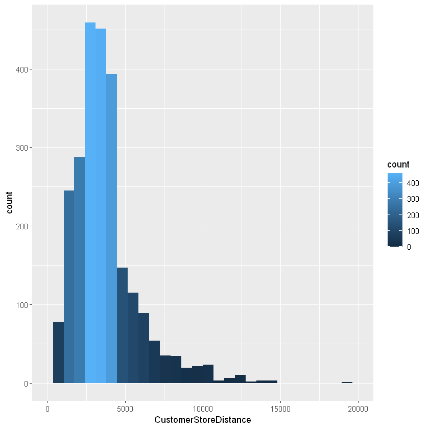

```r
# your ggplot line here

 library(ggplot2)
 ggplot(data=sale_data, aes(x =CustomerStoreDistance , fill = ..count..)) + geom_histogram(alpha=1) + xlim(0,20000)
 + scale_fill_gradient(low="purple",high="darkblue")
 + ggtitle("Customer Store Distance of Laptop Sales") + labs(x="Customer Store Distance", y="Count")
 #Insight: When customer store distance is approximately between 0 - 3000. The more customers stores increases
 #within longer distance. But when distance is over approximately 3000, the longer the distance, the less
 # customer stores.
```

**Explanation**:

1. (0.5 points) Plot a `boxplot` of the variable `Retail Price` (only) and provide a description of the insights you get from it. Use `ggplot`. For this plot, you do not need to label the X axis (but you do need a title and label the Y axis). Your plot should display outliers (if any) in orange, with a shape of a triangle and size `3`

(HINT: to understand how to change shapes see http://www.sthda.com/english/wiki/ggplot2-point-shapes)

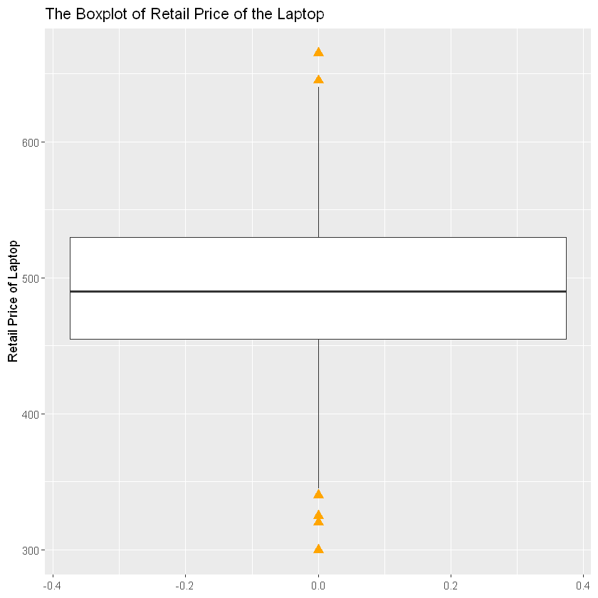

```r
ggplot(data = sale_data, aes(x=, y=Retail.Price, color=)) +
  geom_boxplot(notch = FALSE, outlier.colour="orange", outlier.shape="triangle", outlier.size=3) +
  ggtitle("The Boxplot of Retail Price of the Laptop") +
  labs(y = "Retail Price of Laptop")
#Insights:
#1.The mean of retail price of the laptop is less than 500.
#2.The lowest retail price of the laptop is about 300.
#3.The highest retail price of the laptop is over 650.
#4.The majority of retail price of the laptop is around 450 -550.
```

1. (1 points) Plot a boxplot to compare the retail price of laptops divided in groups based on the variable `HD.Size..GB.`; provide a description of the insights you get from it. Use `ggplot`; each individual box in your plot should have a different fill color, based on `HD.Size..GB`. The outliers should be identified with a shape and color of your choice.

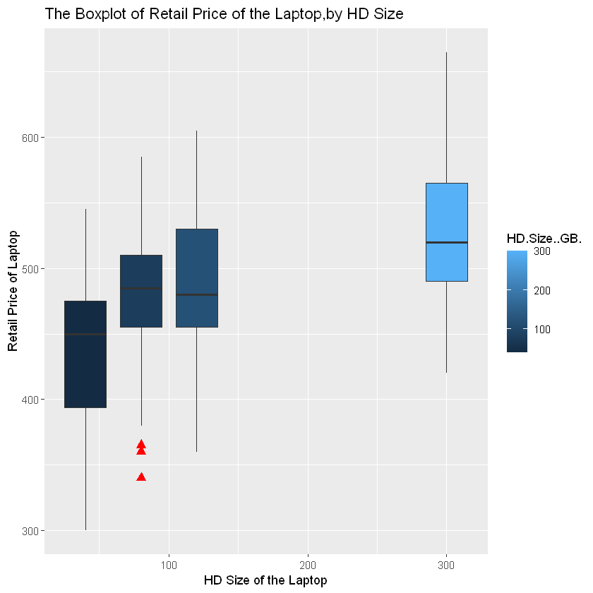

```r
ggplot(data = sale_data, aes(x=HD.Size..GB., y=Retail.Price, group= HD.Size..GB., fill =HD.Size..GB.)) +
  geom_boxplot(notch = FALSE, outlier.colour="red", outlier.shape="triangle", outlier.size=3) +
  ggtitle("The Boxplot of Retail Price of the Laptop,by HD Size") +
  labs(x = "HD Size of the Laptop", y = "Retail Price of Laptop")
 #Insights:
 #1.HD size of the laptop can affect the retail price of the laptop.
 #2.When HD size of the laptop is smaller than 50, the average price of the laptop is the lowest.
 #3.When HD size of the laptop is greater than 50 but smaller than 150, the average price of laptop is higher a little than the laptop which has HD
 #size is smaller than 50.
 #4.The laptop that its HD size is 300 has the highest retail price.
```

Finally, we want to understand what type of relationship exists between the retail price and the battery life hours of a laptop.

1. (0.5 points) Plot the relationship between battery life hours and the retail price. Use ggplot; the color of the points should change based on battery life hours. What do you see? Provide an explanation.

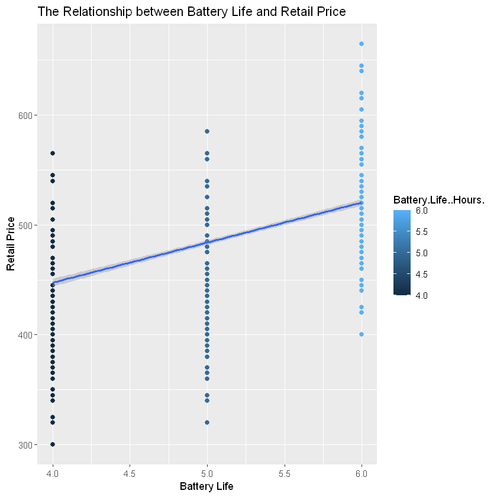

```r
ggplot(data = sale_data, aes(x=Battery.Life..Hours., y=Retail.Price, color=Battery.Life..Hours.)) + geom_point(size=2)+
 ggtitle("The Relationship between Battery Life and Retail Price") + labs(x="Battery Life",y="Retail Price") +  geom_smooth(method=lm)
#Insights:
#1.There is a positive relationship between battery life and retail price of the laptop.
#2.
```

1. (1.1 points) Plot a histogram of retail price, divided by categories based on the battery life hours and provide a description of the insights you get from it. Use ggplot. Your histogram should have a different color for each category and an alpha = 0.8.

HINT: you may need to create a new "categorical" variable for the battery life hours, that is currently a numerical variable.

Here an example of how to do that:

Assume you have a dataset called “mydata” and you have a numerical variable “age”. You want to group the variable age into categories: Elder, Middle Aged, Young. You first need to create a new variable that will contain the categories, let us call it “agecat” and then assign the records to the different categories based on some rules you decide. For example, all records for which age > 75, are assigned to the category “Elder”.

See example code below:

```
mydata$agecat[age > 75] <- “Elder”
mydata$agecat[age > 45 & age <=75] <- “Middle Aged”
mydata$agecat[age <= 45] <- “Young”
```

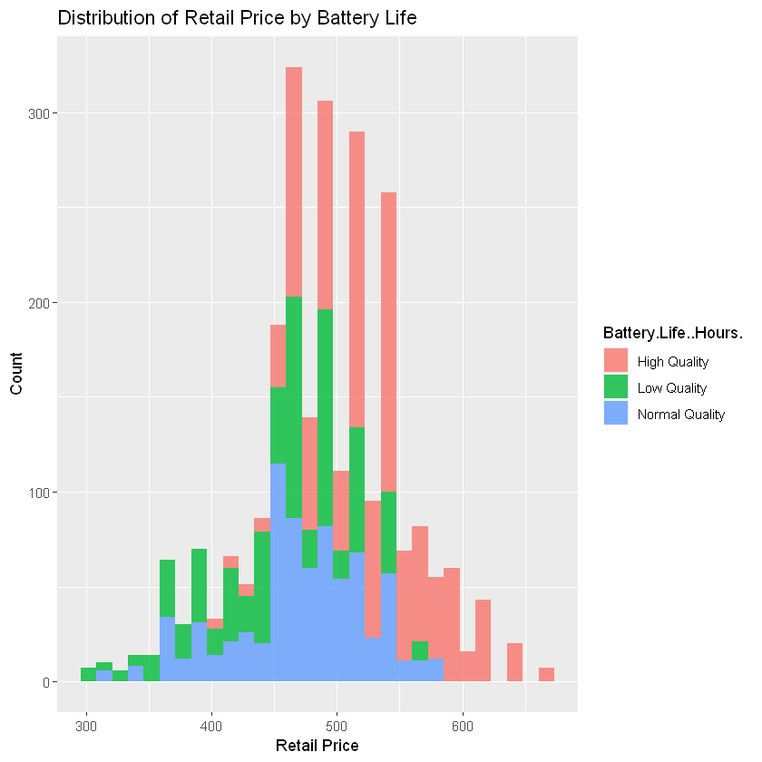

```r
sale_data$Battery.Life..Hours.[sale_data$Battery.Life..Hours.==6] <- "High Quality"
sale_data$Battery.Life..Hours.[sale_data$Battery.Life..Hours.== 5 ] <- "Normal Quality"
sale_data$Battery.Life..Hours.[sale_data$Battery.Life..Hours.==4] <- "Low Quality"
ggplot(data = sale_data, aes(x=Retail.Price, fill=Battery.Life..Hours.)) + geom_histogram(alpha=0.8)+
ggtitle("Distribution of Retail Price by Battery Life") + labs(x="Retail Price",y="Count")
#Insights:
#1.There are three types of battery life, which can last 4,5,6 hours each.
#2.If the retail price of laptops are less than 450, battery life of laptops is more likely less than 6 hours, which means the low or normal quality.
#3.When the retail price of laptops are more than 450,the majority of laptops can have more than 5 hours battery of life.
#4.When the retail price of laptops are more than 600, the battery of life will last at least 6 hours.
```

**ANSWER**:

# End of HW1

Now, head to the `File` menu, and export notebook as PDF. Use this PDF as your submission.